# TP1: Introduction à R et Statistiques Descriptives

```r
# repertoire de travail courant
print(getwd())
```

```
[1] "/home/alpron/code/statistics-esir/TP1/R"
```

```r
# utiliser dans un terminal setwd pour fixer le repertoire courant
# setwd('')
```

## Exercices de TD

### TD1 - exercice 1

```r
df <- read.table("../data/td1ex1_data.dat", header=T, dec=".")
# résumé des charactéristiques des données
print(summary(df))
```

```
      taux
 Min.   :0.050
 1st Qu.:0.785
 Median :0.980
 Mean   :1.223
 3rd Qu.:1.442
 Max.   :5.210
```

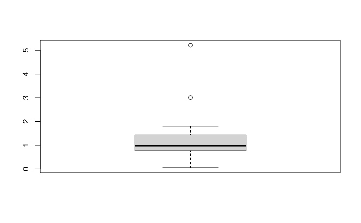

```r
# boîte à moustache (boxplot)
boxplot(df)
```

```r
# recupération des valeurs aberrantes
quantiles <- quantile(df$taux)
# remarque il existe egalement une fonction IQR
iqr <- (quantiles[3] - quantiles[1]) # Q3 - Q1
# moustache inférieure
lower_bound <- (quantiles[1] - 1.5*iqr)
# moustache supérieure
upper_bound <- (quantiles[3] + 1.5*iqr)
# valeurs aberrantes
outliers <- df$taux[(df$taux<lower_bound) | (df$taux>upper_bound)]
cat("Valeurs aberrantes detectées en appliquant la règle des boîtes à moustaches",outliers)
```

```
Valeurs aberrantes detectées en appliquant la règle des boîtes à moustaches 5.21 3.01
```

```r
# Remarque: on peut vérifier la validité de la détection en affichant les valeurs triées et en s'aidant du boxplot affiché
# Il existe egalement des packages R (p.ex. shiny) permettant un affichage interactif des valeurs
print(sort(df$taux))
```

```
 [1] 0.05 0.13 0.26 0.69 0.73 0.74 0.74 0.80 0.83 0.88 0.91 0.93 0.95 0.97 0.99 1.01 1.04 1.14 1.30 1.33 1.44 1.45 1.51 1.68 1.72 1.81 3.01 5.21
```

On observe sur la boîte à moustache (ronds blancs) la présence de 2 valeurs aberrantes (outliers).

### TD1 exercice 2

```r
df <- read.table("../data/td1ex2_data.dat", header=F)

par(mfrow=c(1,3))

# défaut
hist(df$V1, col="lightgreen",ylim=c(0,80), main="Méthode par défaut", xlab="Taille mesurée (cm)")

# avec nombre de classes fixes identiques au TD
hist(df$V1, col="lightgreen",ylim=c(0,80),main=paste("10 classes"), xlab="Taille mesurée (cm)")
```

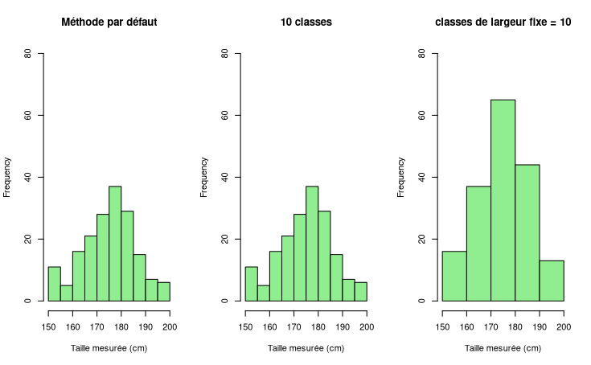

```r
#' Compute breaks associated with constants class width from the min
#'
#' @param x A numeric vector.
#' @param step A integer.
#' @returns bins, A numeric vector.
#' @examples
#' get_breaks(x, 10)
get_breaks <- function(x, step=10){
  x_min <- min(x)
  x_max <- max(x)
  bin_max <-(((x_max - x_min)%/% step + 1)*step + x_min)
  bins <- seq(x_min, bin_max, step)
  return(bins)
}
class_width <- 10
hist(df$V1, col="lightgreen",ylim=c(0,80),main=paste("classes de largeur fixe =", class_width), breaks=get_breaks(df$V1, class_width), xlab="Taille mesurée (cm)")
```

###TD1 - exercice 4

```r
df <- read.table("../data/td1ex4_data.txt", header=T)
# affichage de la distribution jointe
plot(df$Statistiques,df$Anglais)
# calcul du coefficient de correlation
rxy <- cor(df$Anglais,df$Statistiques)
# estimation du modèle linéaire : ax + b
regression <- lm(formula=df$Anglais~df$Statistiques)
print(regression$coefficients)
```

```
    (Intercept) df$Statistiques
      7.1333333      -0.2969697
```

```r
# ajout de la droite de regression avec coefficient estimés précédement
abline(regression$coefficients[1], regression$coefficients[2], col='blue')
```

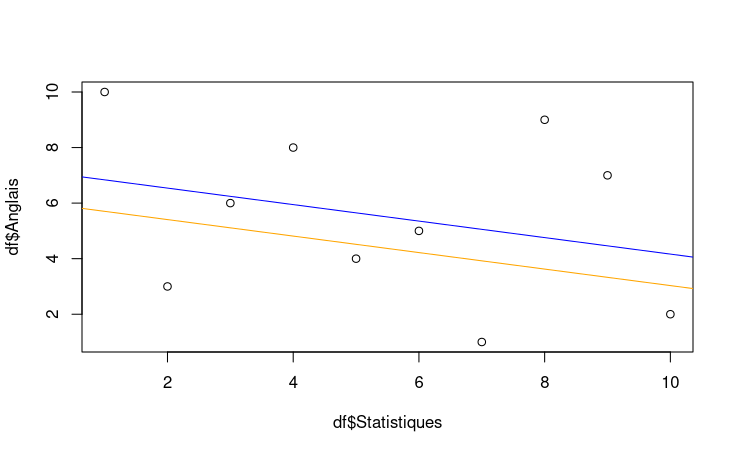

```r
# ajout d'une droite avec formule donnée
abline(6,rxy*(sd(df$Statistiques)/(sd(df$Anglais))), col='orange')
```

Les deux droites (bleu - regression et orange coefficient directeur fixé) sont parallèles, leur coefficient directeur semblent donc identiques. On en déduit que le coefficient du modèle de régression est estimé selon la formule $r_{xy}\frac {\hat{\sigma}_y}{\hat{\sigma}_x}$.

## Description d’un fichier de données : les iris de Fischer

```r
data('iris')
print(summary(iris))
```

```
  Sepal.Length    Sepal.Width     Petal.Length    Petal.Width          Species
 Min.   :4.300   Min.   :2.000   Min.   :1.000   Min.   :0.100   setosa    :50
 1st Qu.:5.100   1st Qu.:2.800   1st Qu.:1.600   1st Qu.:0.300   versicolor:50
 Median :5.800   Median :3.000   Median :4.350   Median :1.300   virginica :50
 Mean   :5.843   Mean   :3.057   Mean   :3.758   Mean   :1.199
 3rd Qu.:6.400   3rd Qu.:3.300   3rd Qu.:5.100   3rd Qu.:1.800
 Max.   :7.900   Max.   :4.400   Max.   :6.900   Max.   :2.500
```

### Q1

150 iris sont décrits au moyen de 5 variables: 4 variables quantitatives continues (longeur et largeur des petales et des sépales) et 1 variable catégorielle (espèce)

### Q2

La fonction summary(iris) indique trois espèces d’iris avec un effectif de 50 iris chacune.Le diagramme en camembert correspondant est visible ci-dessous.

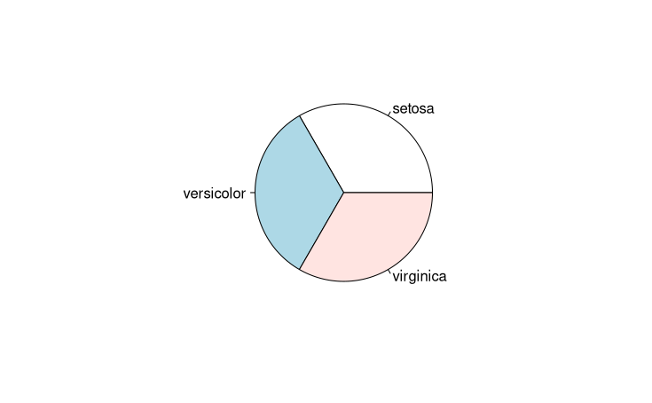

```r
species <- iris$Species
species.freq = table(species)
pie(species.freq)
```

### Q3 Selection de données

```r
# selection de l'ensemble des individues et variables d'une espece dans le dataset iris
setosa_df <-iris[iris$Species == 'setosa', ]
# selection de l'ensemble des individues et d'une variable particulière d'une espece dans le dataset iris
setosa_length <-iris[iris$Species == 'setosa', "Petal.Length"]
```

### Q4 Affichage des histogrammes par variable et par espèce

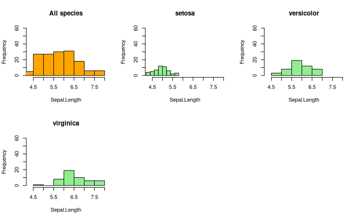

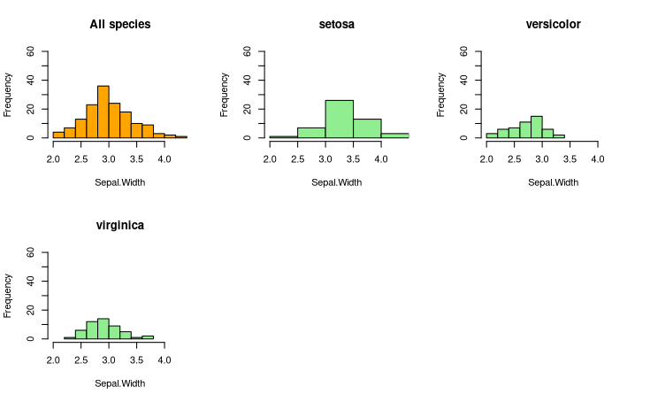

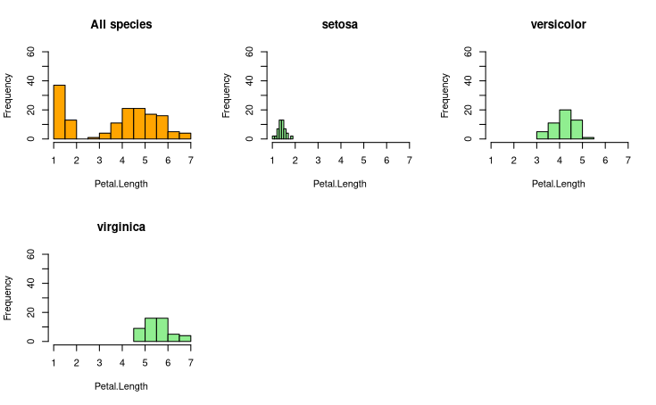

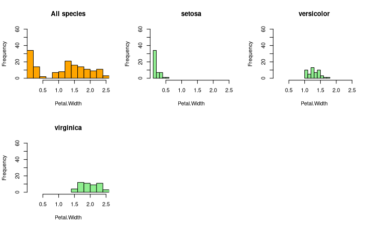

```r
for (variable in names(iris)[-5]){
    # Select a variable of interest
    var_selection <-subset(iris, select=variable)[,1]
    # Histogram
      par(mfrow = c(2, 3))
    hist(var_selection, ylim=c(0,60),xlim=c(min(var_selection),max(var_selection)), main="All species", col="orange",xlab=variable)
    # Sub Histogram per Species
    for (espece in unique(iris$Species)){
        selection  <- subset(iris, Species == espece,select=variable)[,1]
        hist(selection, ylim=c(0,60),xlim=c(min(var_selection), max(var_selection)), main=espece, col="lightgreen",
    xlab=variable)
    }
}
```

Le code précédent produit 4 figures (un graphique par variable présente dans le dataset iris). Pour chaque figure l’histogramme de la variable considérée indépendamment de l’espèce (orange) ainsi que 3 histogramme complémentaires (1 par espèce d’iris)

### Q5 Boîtes à moustache par variable et par espèce

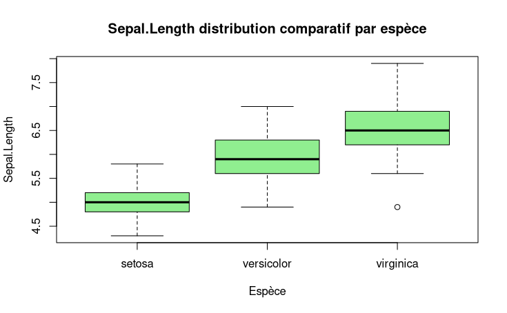

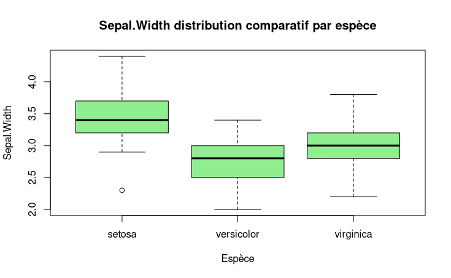

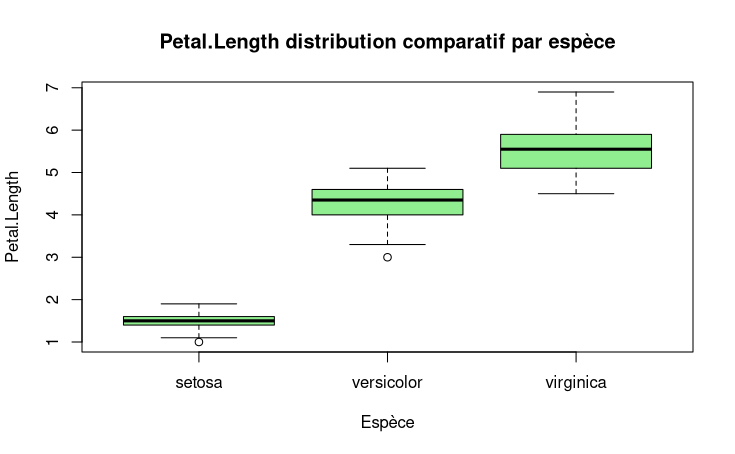

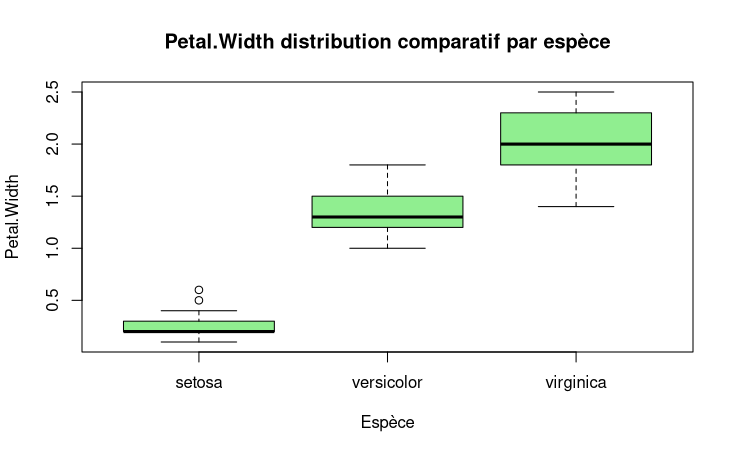

```r
variable_names <-
for (variable in names(iris)[-5]){
    # Select a variable of interest
    var_selection <- iris[, c(variable, "Species")]
    boxplot(var_selection[, variable] ~ var_selection$Species, col='lightgreen', xlab="Espèce", ylab=variable, main=paste(variable, "distribution comparatif par espèce"))
}
```

On souhaite trouver un critère pour discriminer les espèces d’iris à partir des variables du datasets iris. L’observation des boxplots nous montre que les distributions des variables Petal.Width et Petal.Length sont très différentes selon les 3 espèces. En particulier la longueur des petales (Petal.Length) ont selon les espèces d’iris des distributions distinctes, monomodales, symétriques avec peu de valeurs aberrantes. La longueur des pétales (et eventuellement la largeur des ) semblent donc particulièrement pertinent pour discriminer les epsèces de façon simple.

## Titanic

### Q1

```r
df <- read.table('../data/titanic.txt', header=T)
summary(df)
```

```
    Class               Sex                Age              Survived
 Length:2201        Length:2201        Length:2201        Length:2201
 Class :character   Class :character   Class :character   Class :character
 Mode  :character   Mode  :character   Mode  :character   Mode  :character
```

### Q2

```r
for (i in c(1,2,3)){
  freq_table <-table(df$Survived, df[,i])
  print(freq_table)
}
```

```
      crew first second third
  no   673   122    167   528
  yes  212   203    118   178

      female male
  no     126 1364
  yes    344  367

      adult child
  no   1438    52
  yes   654    57
```

On croise la variable Survived (Survie) avec les autres variables (Sexe, Age, Class). On souhaite maximiser la probabilité de survivre sachant le sexe, la classe et l’age connu. Du tableau, on note qu’il vaut a priori mieux être une femme (73 % de chance de survie) qu’un homme (21% de chance de survie). Les membres de la premières classe on également 62 % de survivre contre 25% pour un membre de la troisième classe. Enfin on remarque qu’un enfant à 50% de survivre. Pour pouvoir affiner l’analyse il faudrait connaitre les tables de croisement de la variable survie relativement à l’ensemble des variables (Class, Sex, Age). On ne peut que supposer qu’une femme de la première classe ou un enfant de la première classe à une chance plus élevée de survivre.

```r
# Mosaic plot with all possible factors
# Color do not encode anything but help visualisation
# Hard to see something on it
mosaicplot(~ Survived + Sex + Class + Age, data=df, col=c('lightblue','pink'), off=c(1,1,1,1))
```

[output not shown]

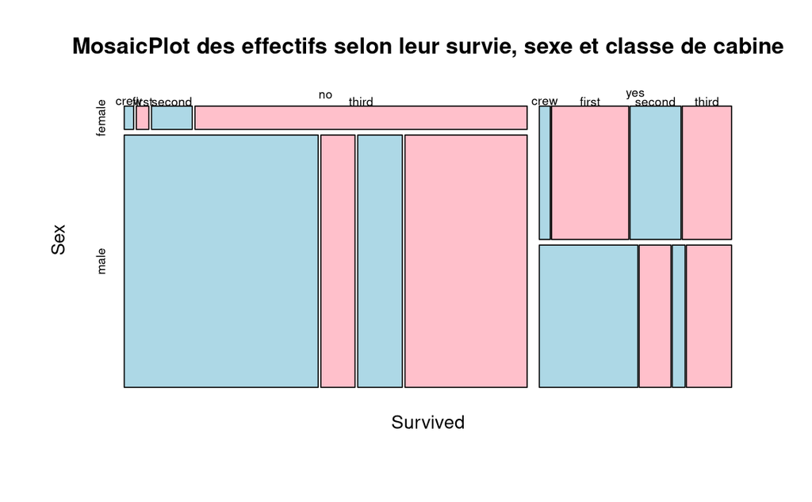

```r
# Mosaic plot avec seulement la survie, sexe et classe de cabine
# Les couleurs n'encode aucune information et aident uniquement à la distinction des blocs
mosaicplot(~ Survived + Sex + Class, data=df, col=c('lightblue','pink'), off=c(2,2,2,2), main="MosaicPlot des effectifs selon leur survie, sexe et classe de cabine")
```

### Q3

Si les variables étaient indépendantes, le graphique devrait être composé de case carrées (aire similaires au travers des différentes variables marginales). Sur le deuxième mosaicplot on confirme les constatations effectués sur les croisements simples: On s’intéresse à maximiser la probabilité de survivre sachant que la catégorie est connue. pour survivre mieux vaut être (et de loin) une femme membre de la première classe, dans une moindre mesure une femme membre de la seconde classe ou de l’équipage.